# Risk Factor Analysis

## Outcome Variable

**Outcome Variable:** ever_wasted

## Predictor Variables

**Intervention Variable:** predfeed3

**Adjustment Set:**

- arm
- sex
- month
- brthmon
- W_mage
- meducyrs
- feducyrs
- hhwealth_quart
- hfoodsec
- W_mhtcm
- W_mwtkg
- W_mbmi
- vagbrth
- W_gagebrth
- W_birthwt
- W_birthlen
- W_nrooms
- W_nchldlt5
- W_parity
- impfloor
- impsan
- safeh20
- delta_W_mage
- delta_meducyrs
- delta_feducyrs
- delta_hhwealth_quart
- delta_hfoodsec
- delta_W_mhtcm
- delta_W_mwtkg
- delta_W_mbmi
- delta_vagbrth
- delta_W_gagebrth
- delta_W_birthwt
- delta_W_birthlen
- delta_W_nrooms
- delta_W_nchldlt5
- delta_W_parity
- delta_impfloor
- delta_impsan
- delta_safeh20

## Stratifying Variables

The analysis was stratified on these variable(s):

- agecat
- studyid
- country

## Data Summary

| agecat | studyid | country | predfeed3 | ever_wasted | n_cell | n |
| --- | --- | --- | --- | --- | --- | --- |
| 0-24 months (no birth wast) | EE | PAKISTAN | 1 | 0 | 18 | 39 |
| 0-24 months (no birth wast) | EE | PAKISTAN | 1 | 1 | 21 | 39 |
| 0-24 months (no birth wast) | EE | PAKISTAN | 0 | 0 | 0 | 39 |
| 0-24 months (no birth wast) | EE | PAKISTAN | 0 | 1 | 0 | 39 |
| 0-24 months (no birth wast) | GMS-Nepal | NEPAL | 1 | 0 | 147 | 453 |
| 0-24 months (no birth wast) | GMS-Nepal | NEPAL | 1 | 1 | 229 | 453 |
| 0-24 months (no birth wast) | GMS-Nepal | NEPAL | 0 | 0 | 39 | 453 |
| 0-24 months (no birth wast) | GMS-Nepal | NEPAL | 0 | 1 | 38 | 453 |
| 0-24 months (no birth wast) | JiVitA-3 | BANGLADESH | 1 | 0 | 11036 | 14768 |
| 0-24 months (no birth wast) | JiVitA-3 | BANGLADESH | 1 | 1 | 2328 | 14768 |
| 0-24 months (no birth wast) | JiVitA-3 | BANGLADESH | 0 | 0 | 1165 | 14768 |
| 0-24 months (no birth wast) | JiVitA-3 | BANGLADESH | 0 | 1 | 239 | 14768 |
| 0-24 months (no birth wast) | JiVitA-4 | BANGLADESH | 1 | 0 | 109 | 164 |
| 0-24 months (no birth wast) | JiVitA-4 | BANGLADESH | 1 | 1 | 38 | 164 |
| 0-24 months (no birth wast) | JiVitA-4 | BANGLADESH | 0 | 0 | 13 | 164 |
| 0-24 months (no birth wast) | JiVitA-4 | BANGLADESH | 0 | 1 | 4 | 164 |
| 0-24 months (no birth wast) | MAL-ED | BANGLADESH | 1 | 0 | 152 | 244 |
| 0-24 months (no birth wast) | MAL-ED | BANGLADESH | 1 | 1 | 48 | 244 |
| 0-24 months (no birth wast) | MAL-ED | BANGLADESH | 0 | 0 | 37 | 244 |
| 0-24 months (no birth wast) | MAL-ED | BANGLADESH | 0 | 1 | 7 | 244 |
| 0-24 months (no birth wast) | MAL-ED | BRAZIL | 1 | 0 | 89 | 202 |
| 0-24 months (no birth wast) | MAL-ED | BRAZIL | 1 | 1 | 9 | 202 |
| 0-24 months (no birth wast) | MAL-ED | BRAZIL | 0 | 0 | 100 | 202 |
| 0-24 months (no birth wast) | MAL-ED | BRAZIL | 0 | 1 | 4 | 202 |
| 0-24 months (no birth wast) | MAL-ED | INDIA | 1 | 0 | 94 | 212 |
| 0-24 months (no birth wast) | MAL-ED | INDIA | 1 | 1 | 56 | 212 |
| 0-24 months (no birth wast) | MAL-ED | INDIA | 0 | 0 | 36 | 212 |
| 0-24 months (no birth wast) | MAL-ED | INDIA | 0 | 1 | 26 | 212 |
| 0-24 months (no birth wast) | MAL-ED | NEPAL | 1 | 0 | 88 | 227 |
| 0-24 months (no birth wast) | MAL-ED | NEPAL | 1 | 1 | 25 | 227 |

[output cut: 58 more lines]

The following strata were considered:

- agecat: 0-24 months (no birth wast), studyid: EE, country: PAKISTAN
- agecat: 0-24 months (no birth wast), studyid: GMS-Nepal, country: NEPAL
- agecat: 0-24 months (no birth wast), studyid: JiVitA-3, country: BANGLADESH
- agecat: 0-24 months (no birth wast), studyid: JiVitA-4, country: BANGLADESH
- agecat: 0-24 months (no birth wast), studyid: MAL-ED, country: BANGLADESH
- agecat: 0-24 months (no birth wast), studyid: MAL-ED, country: BRAZIL
- agecat: 0-24 months (no birth wast), studyid: MAL-ED, country: INDIA
- agecat: 0-24 months (no birth wast), studyid: MAL-ED, country: NEPAL
- agecat: 0-24 months (no birth wast), studyid: MAL-ED, country: PERU
- agecat: 0-24 months (no birth wast), studyid: MAL-ED, country: SOUTH AFRICA
- agecat: 0-24 months (no birth wast), studyid: MAL-ED, country: TANZANIA, UNITED REPUBLIC OF
- agecat: 0-6 months (no birth wast), studyid: EE, country: PAKISTAN
- agecat: 0-6 months (no birth wast), studyid: GMS-Nepal, country: NEPAL
- agecat: 0-6 months (no birth wast), studyid: JiVitA-3, country: BANGLADESH
- agecat: 0-6 months (no birth wast), studyid: JiVitA-4, country: BANGLADESH
- agecat: 0-6 months (no birth wast), studyid: MAL-ED, country: BANGLADESH
- agecat: 0-6 months (no birth wast), studyid: MAL-ED, country: BRAZIL
- agecat: 0-6 months (no birth wast), studyid: MAL-ED, country: INDIA
- agecat: 0-6 months (no birth wast), studyid: MAL-ED, country: NEPAL
- agecat: 0-6 months (no birth wast), studyid: MAL-ED, country: PERU
- agecat: 0-6 months (no birth wast), studyid: MAL-ED, country: SOUTH AFRICA
- agecat: 0-6 months (no birth wast), studyid: MAL-ED, country: TANZANIA, UNITED REPUBLIC OF

### Dropped Strata

Some strata were dropped due to rare outcomes:

- agecat: 0-24 months (no birth wast), studyid: EE, country: PAKISTAN
- agecat: 0-24 months (no birth wast), studyid: JiVitA-4, country: BANGLADESH
- agecat: 0-24 months (no birth wast), studyid: MAL-ED, country: BRAZIL
- agecat: 0-6 months (no birth wast), studyid: EE, country: PAKISTAN
- agecat: 0-6 months (no birth wast), studyid: JiVitA-4, country: BANGLADESH
- agecat: 0-6 months (no birth wast), studyid: MAL-ED, country: BANGLADESH
- agecat: 0-6 months (no birth wast), studyid: MAL-ED, country: BRAZIL
- agecat: 0-6 months (no birth wast), studyid: MAL-ED, country: PERU
- agecat: 0-6 months (no birth wast), studyid: MAL-ED, country: TANZANIA, UNITED REPUBLIC OF

## Methods Detail

We're interested in the causal parameters $E[Y_a]$ for all values of $a \in \mathcal{A}$. These parameters represent the mean outcome if, possibly contrary to fact, we intervened to set all units to have $A=a$. Under the randomization and positivity assumptions, these are identified by the statistical parameters $\psi_a=E_W[E_{Y|A,W}(Y|A=a,W)]$. In addition, we're interested in the mean of $Y$, $E[Y]$ under no intervention (the observed mean). We will estimate these parameters by using SuperLearner to fit the relevant likelihood factors -- $E_{Y|A,W}(Y|A=a,W)$ and $p(A=a|W)$, and then updating our likelihood fit using a joint TMLE.

For unadjusted analyses ($W=\{\}$), initial likelihoods were estimated using Lrnr_glm to estimate the simple $E(Y|A)$ and Lrnr_mean to estimate $p(A)$. For adjusted analyses, a small library containing Lrnr_glmnet, Lrnr_xgboost, and Lrnr_mean was used.

Having estimated these parameters, we will then use the delta method to estimate relative risks and attributable risks relative to a prespecified baseline level of $A$.

# Results Detail

## Results Plots

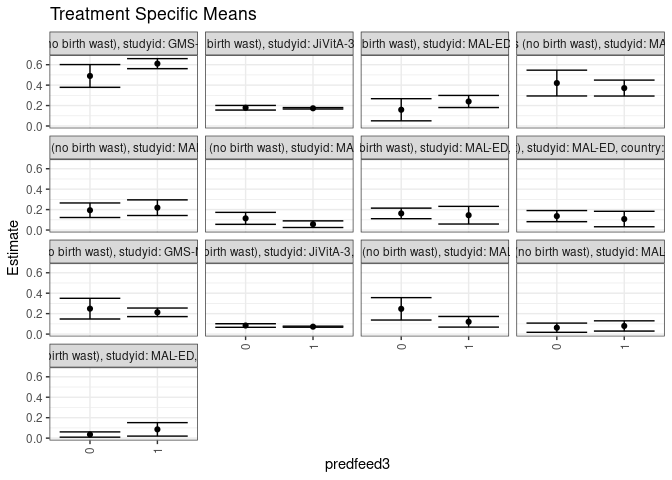

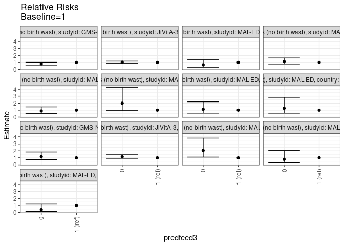

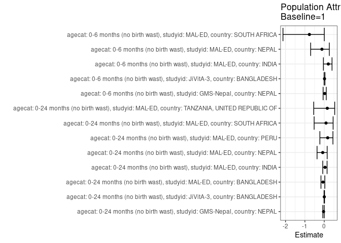

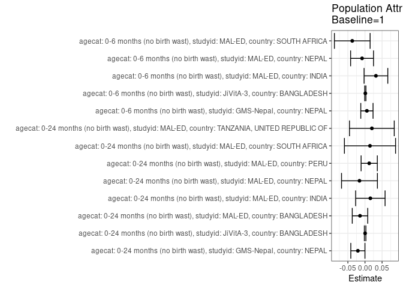

## Results Table

### Parameter: TSM

| agecat | studyid | country | intervention_level | baseline_level | estimate | ci_lower | ci_upper |
| --- | --- | --- | --- | --- | --- | --- | --- |
| 0-24 months (no birth wast) | GMS-Nepal | NEPAL | 1 | NA | 0.6101755 | 0.5610165 | 0.6593346 |
| 0-24 months (no birth wast) | GMS-Nepal | NEPAL | 0 | NA | 0.4897971 | 0.3784368 | 0.6011575 |
| 0-24 months (no birth wast) | JiVitA-3 | BANGLADESH | 1 | NA | 0.1734078 | 0.1664465 | 0.1803692 |
| 0-24 months (no birth wast) | JiVitA-3 | BANGLADESH | 0 | NA | 0.1786831 | 0.1559096 | 0.2014566 |
| 0-24 months (no birth wast) | MAL-ED | BANGLADESH | 1 | NA | 0.2400000 | 0.1806887 | 0.2993113 |
| 0-24 months (no birth wast) | MAL-ED | BANGLADESH | 0 | NA | 0.1590909 | 0.0507953 | 0.2673865 |
| 0-24 months (no birth wast) | MAL-ED | INDIA | 1 | NA | 0.3710842 | 0.2932048 | 0.4489635 |
| 0-24 months (no birth wast) | MAL-ED | INDIA | 0 | NA | 0.4202138 | 0.2940518 | 0.5463758 |
| 0-24 months (no birth wast) | MAL-ED | NEPAL | 1 | NA | 0.2187743 | 0.1422287 | 0.2953199 |
| 0-24 months (no birth wast) | MAL-ED | NEPAL | 0 | NA | 0.1938729 | 0.1226995 | 0.2650462 |
| 0-24 months (no birth wast) | MAL-ED | PERU | 1 | NA | 0.0573170 | 0.0248994 | 0.0897346 |
| 0-24 months (no birth wast) | MAL-ED | PERU | 0 | NA | 0.1144319 | 0.0558704 | 0.1729934 |
| 0-24 months (no birth wast) | MAL-ED | SOUTH AFRICA | 1 | NA | 0.1452200 | 0.0586077 | 0.2318324 |
| 0-24 months (no birth wast) | MAL-ED | SOUTH AFRICA | 0 | NA | 0.1627267 | 0.1110043 | 0.2144492 |
| 0-24 months (no birth wast) | MAL-ED | TANZANIA, UNITED REPUBLIC OF | 1 | NA | 0.1076923 | 0.0321596 | 0.1832250 |
| 0-24 months (no birth wast) | MAL-ED | TANZANIA, UNITED REPUBLIC OF | 0 | NA | 0.1363636 | 0.0820391 | 0.1906882 |
| 0-6 months (no birth wast) | GMS-Nepal | NEPAL | 1 | NA | 0.2130521 | 0.1710590 | 0.2550451 |
| 0-6 months (no birth wast) | GMS-Nepal | NEPAL | 0 | NA | 0.2488631 | 0.1475457 | 0.3501804 |
| 0-6 months (no birth wast) | JiVitA-3 | BANGLADESH | 1 | NA | 0.0725063 | 0.0673795 | 0.0776331 |
| 0-6 months (no birth wast) | JiVitA-3 | BANGLADESH | 0 | NA | 0.0839141 | 0.0664784 | 0.1013498 |
| 0-6 months (no birth wast) | MAL-ED | INDIA | 1 | NA | 0.1203735 | 0.0683265 | 0.1724204 |
| 0-6 months (no birth wast) | MAL-ED | INDIA | 0 | NA | 0.2470659 | 0.1373819 | 0.3567500 |
| 0-6 months (no birth wast) | MAL-ED | NEPAL | 1 | NA | 0.0796460 | 0.0296154 | 0.1296766 |
| 0-6 months (no birth wast) | MAL-ED | NEPAL | 0 | NA | 0.0625000 | 0.0175705 | 0.1074295 |
| 0-6 months (no birth wast) | MAL-ED | SOUTH AFRICA | 1 | NA | 0.0857143 | 0.0200123 | 0.1514163 |
| 0-6 months (no birth wast) | MAL-ED | SOUTH AFRICA | 0 | NA | 0.0353535 | 0.0095827 | 0.0611243 |

### Parameter: E(Y)

| agecat | studyid | country | intervention_level | baseline_level | estimate | ci_lower | ci_upper |
| --- | --- | --- | --- | --- | --- | --- | --- |
| 0-24 months (no birth wast) | GMS-Nepal | NEPAL | NA | NA | 0.5894040 | 0.5440524 | 0.6347556 |
| 0-24 months (no birth wast) | JiVitA-3 | BANGLADESH | NA | NA | 0.1738218 | 0.1671074 | 0.1805361 |
| 0-24 months (no birth wast) | MAL-ED | BANGLADESH | NA | NA | 0.2254098 | 0.1728726 | 0.2779471 |
| 0-24 months (no birth wast) | MAL-ED | INDIA | NA | NA | 0.3867925 | 0.3210797 | 0.4525052 |
| 0-24 months (no birth wast) | MAL-ED | NEPAL | NA | NA | 0.2026432 | 0.1502365 | 0.2550498 |
| 0-24 months (no birth wast) | MAL-ED | PERU | NA | NA | 0.0696864 | 0.0401775 | 0.0991954 |
| 0-24 months (no birth wast) | MAL-ED | SOUTH AFRICA | NA | NA | 0.1598513 | 0.1159763 | 0.2037263 |
| 0-24 months (no birth wast) | MAL-ED | TANZANIA, UNITED REPUBLIC OF | NA | NA | 0.1278539 | 0.0835266 | 0.1721812 |
| 0-6 months (no birth wast) | GMS-Nepal | NEPAL | NA | NA | 0.2186788 | 0.1799683 | 0.2573894 |
| 0-6 months (no birth wast) | JiVitA-3 | BANGLADESH | NA | NA | 0.0735505 | 0.0685774 | 0.0785236 |
| 0-6 months (no birth wast) | MAL-ED | INDIA | NA | NA | 0.1523810 | 0.1036572 | 0.2011047 |
| 0-6 months (no birth wast) | MAL-ED | NEPAL | NA | NA | 0.0711111 | 0.0374542 | 0.1047681 |
| 0-6 months (no birth wast) | MAL-ED | SOUTH AFRICA | NA | NA | 0.0485075 | 0.0227384 | 0.0742766 |

### Parameter: RR

| agecat | studyid | country | intervention_level | baseline_level | estimate | ci_lower | ci_upper |
| --- | --- | --- | --- | --- | --- | --- | --- |
| 0-24 months (no birth wast) | GMS-Nepal | NEPAL | 1 | 1 | 1.0000000 | 1.0000000 | 1.000000 |
| 0-24 months (no birth wast) | GMS-Nepal | NEPAL | 0 | 1 | 0.8027151 | 0.6316685 | 1.020079 |
| 0-24 months (no birth wast) | JiVitA-3 | BANGLADESH | 1 | 1 | 1.0000000 | 1.0000000 | 1.000000 |
| 0-24 months (no birth wast) | JiVitA-3 | BANGLADESH | 0 | 1 | 1.0304215 | 0.9023269 | 1.176700 |
| 0-24 months (no birth wast) | MAL-ED | BANGLADESH | 1 | 1 | 1.0000000 | 1.0000000 | 1.000000 |
| 0-24 months (no birth wast) | MAL-ED | BANGLADESH | 0 | 1 | 0.6628788 | 0.3213097 | 1.367554 |
| 0-24 months (no birth wast) | MAL-ED | INDIA | 1 | 1 | 1.0000000 | 1.0000000 | 1.000000 |
| 0-24 months (no birth wast) | MAL-ED | INDIA | 0 | 1 | 1.1323947 | 0.7845411 | 1.634481 |
| 0-24 months (no birth wast) | MAL-ED | NEPAL | 1 | 1 | 1.0000000 | 1.0000000 | 1.000000 |
| 0-24 months (no birth wast) | MAL-ED | NEPAL | 0 | 1 | 0.8861776 | 0.5344270 | 1.469445 |
| 0-24 months (no birth wast) | MAL-ED | PERU | 1 | 1 | 1.0000000 | 1.0000000 | 1.000000 |
| 0-24 months (no birth wast) | MAL-ED | PERU | 0 | 1 | 1.9964728 | 0.9306732 | 4.282818 |
| 0-24 months (no birth wast) | MAL-ED | SOUTH AFRICA | 1 | 1 | 1.0000000 | 1.0000000 | 1.000000 |
| 0-24 months (no birth wast) | MAL-ED | SOUTH AFRICA | 0 | 1 | 1.1205530 | 0.5702380 | 2.201956 |
| 0-24 months (no birth wast) | MAL-ED | TANZANIA, UNITED REPUBLIC OF | 1 | 1 | 1.0000000 | 1.0000000 | 1.000000 |
| 0-24 months (no birth wast) | MAL-ED | TANZANIA, UNITED REPUBLIC OF | 0 | 1 | 1.2662338 | 0.5652023 | 2.836768 |
| 0-6 months (no birth wast) | GMS-Nepal | NEPAL | 1 | 1 | 1.0000000 | 1.0000000 | 1.000000 |
| 0-6 months (no birth wast) | GMS-Nepal | NEPAL | 0 | 1 | 1.1680857 | 0.7430228 | 1.836315 |
| 0-6 months (no birth wast) | JiVitA-3 | BANGLADESH | 1 | 1 | 1.0000000 | 1.0000000 | 1.000000 |
| 0-6 months (no birth wast) | JiVitA-3 | BANGLADESH | 0 | 1 | 1.1573350 | 0.9311978 | 1.438389 |
| 0-6 months (no birth wast) | MAL-ED | INDIA | 1 | 1 | 1.0000000 | 1.0000000 | 1.000000 |
| 0-6 months (no birth wast) | MAL-ED | INDIA | 0 | 1 | 2.0524952 | 1.1030230 | 3.819265 |
| 0-6 months (no birth wast) | MAL-ED | NEPAL | 1 | 1 | 1.0000000 | 1.0000000 | 1.000000 |
| 0-6 months (no birth wast) | MAL-ED | NEPAL | 0 | 1 | 0.7847222 | 0.3020750 | 2.038530 |
| 0-6 months (no birth wast) | MAL-ED | SOUTH AFRICA | 1 | 1 | 1.0000000 | 1.0000000 | 1.000000 |
| 0-6 months (no birth wast) | MAL-ED | SOUTH AFRICA | 0 | 1 | 0.4124579 | 0.1432147 | 1.187878 |

### Parameter: PAR

| agecat | studyid | country | intervention_level | baseline_level | estimate | ci_lower | ci_upper |
| --- | --- | --- | --- | --- | --- | --- | --- |
| 0-24 months (no birth wast) | GMS-Nepal | NEPAL | 1 | NA | -0.0207716 | -0.0414528 | -0.0000903 |
| 0-24 months (no birth wast) | JiVitA-3 | BANGLADESH | 1 | NA | 0.0004140 | -0.0018167 | 0.0026446 |
| 0-24 months (no birth wast) | MAL-ED | BANGLADESH | 1 | NA | -0.0145902 | -0.0371968 | 0.0080165 |
| 0-24 months (no birth wast) | MAL-ED | INDIA | 1 | NA | 0.0157083 | -0.0273560 | 0.0587726 |
| 0-24 months (no birth wast) | MAL-ED | NEPAL | 1 | NA | -0.0161311 | -0.0686047 | 0.0363426 |
| 0-24 months (no birth wast) | MAL-ED | PERU | 1 | NA | 0.0123694 | -0.0113513 | 0.0360901 |
| 0-24 months (no birth wast) | MAL-ED | SOUTH AFRICA | 1 | NA | 0.0146313 | -0.0601651 | 0.0894276 |
| 0-24 months (no birth wast) | MAL-ED | TANZANIA, UNITED REPUBLIC OF | 1 | NA | 0.0201616 | -0.0452865 | 0.0856097 |
| 0-6 months (no birth wast) | GMS-Nepal | NEPAL | 1 | NA | 0.0056268 | -0.0123066 | 0.0235601 |
| 0-6 months (no birth wast) | JiVitA-3 | BANGLADESH | 1 | NA | 0.0010442 | -0.0006782 | 0.0027666 |
| 0-6 months (no birth wast) | MAL-ED | INDIA | 1 | NA | 0.0320075 | -0.0026684 | 0.0666834 |
| 0-6 months (no birth wast) | MAL-ED | NEPAL | 1 | NA | -0.0085349 | -0.0420262 | 0.0249564 |
| 0-6 months (no birth wast) | MAL-ED | SOUTH AFRICA | 1 | NA | -0.0372068 | -0.0894158 | 0.0150022 |

### Parameter: PAF

| agecat | studyid | country | intervention_level | baseline_level | estimate | ci_lower | ci_upper |
| --- | --- | --- | --- | --- | --- | --- | --- |
| 0-24 months (no birth wast) | GMS-Nepal | NEPAL | 1 | NA | -0.0352416 | -0.0711408 | -0.0005456 |
| 0-24 months (no birth wast) | JiVitA-3 | BANGLADESH | 1 | NA | 0.0023815 | -0.0105297 | 0.0151278 |
| 0-24 months (no birth wast) | MAL-ED | BANGLADESH | 1 | NA | -0.0647273 | -0.1694188 | 0.0305918 |
| 0-24 months (no birth wast) | MAL-ED | INDIA | 1 | NA | 0.0406117 | -0.0775359 | 0.1458048 |
| 0-24 months (no birth wast) | MAL-ED | NEPAL | 1 | NA | -0.0796034 | -0.3715734 | 0.1502142 |
| 0-24 months (no birth wast) | MAL-ED | PERU | 1 | NA | 0.1775005 | -0.2254199 | 0.4479400 |
| 0-24 months (no birth wast) | MAL-ED | SOUTH AFRICA | 1 | NA | 0.0915305 | -0.5215483 | 0.4575809 |
| 0-24 months (no birth wast) | MAL-ED | TANZANIA, UNITED REPUBLIC OF | 1 | NA | 0.1576923 | -0.5426579 | 0.5400910 |
| 0-6 months (no birth wast) | GMS-Nepal | NEPAL | 1 | NA | 0.0257307 | -0.0597626 | 0.1043271 |
| 0-6 months (no birth wast) | JiVitA-3 | BANGLADESH | 1 | NA | 0.0141969 | -0.0094401 | 0.0372803 |
| 0-6 months (no birth wast) | MAL-ED | INDIA | 1 | NA | 0.2100492 | -0.0437797 | 0.4021514 |
| 0-6 months (no birth wast) | MAL-ED | NEPAL | 1 | NA | -0.1200221 | -0.7011560 | 0.2625900 |
| 0-6 months (no birth wast) | MAL-ED | SOUTH AFRICA | 1 | NA | -0.7670330 | -2.1314677 | 0.0028939 |